# IS606 - Statistics & Probability for Data Analytics

January, 2016

## Agenda

- Introduction
- Syllabus
- Assignments
  - Homework
  - Labs
  - Data Project
  - Final exam
  - Meetup Presentation
- The `IS606` R Package
- Using R Markdown

## Introduction

A little about me:

- Currently Executive Director at [Excelsior College](http://excelsior.edu)
  - Principal Investigator for a Department of Education Grant (part of their FIPSE First in the World program) to develop a Diagnostic Assessment and Achievement of College Skills ([www.DAACS.net](http://www.daacs.net))
- Authored over a dozen R packages including:
  - likert
  - sqlutils
  - timeline
- Specialize in propensity score methods. Three new methods/R packages developed include:
  - multilevelPSA
  - TriMatch
  - PSAboot

## Also a Father…

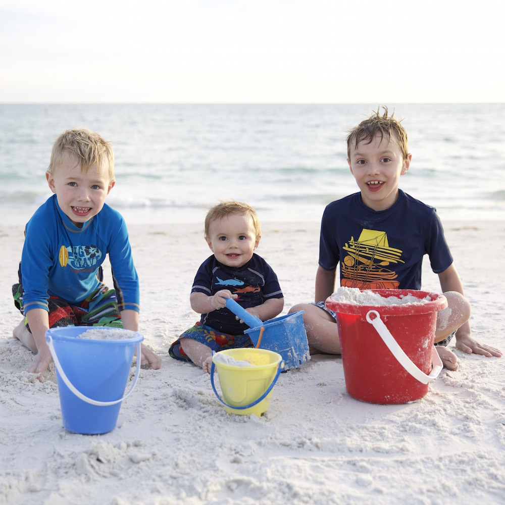

## And photographer.

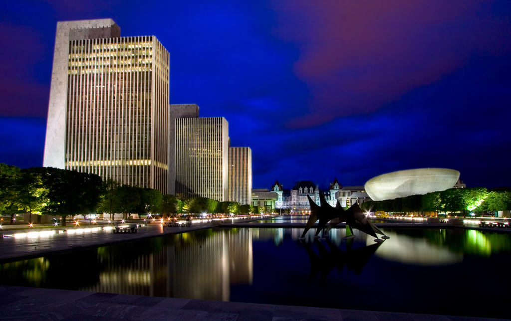

## Syllabus

Syllabus and course materials are on Github: https://github.com/jbryer/IS606Spring2015

We will use Blackboard for the discussion forums and to submit assignments.

## Assignments

- Getting Aquainted (1%)
- [Homework](https://github.com/jbryer/IS606Spring2015#homework-assignments) (16%)
  - Approximately six problems per chapter.
  - Answers can be handwritten or typed (I suggest using R Markdown)
  - Submit a PDF on Blackboard.
- [Labs](https://github.com/jbryer/IS606Spring2015#labs) (40%)
  - Labs are designed to introduce to you doing statistics with R.
  - Answer the questions in the main text as well as the "On Your Own" section.
  - Submit both the R Markdown file and PDF of the output on Blackboard.
- [Data Project](https://htmlpreview.github.io/?https://github.com/jbryer/IS606Spring2015/blob/master/Project/IS606_Data_Project.html) (20%)
  - This allows you to analyze a dataset of your choosing. Projects will be shared with the class. This provides an opportunity for everyone to see different approaches to analyzing different datasets.
  - Proposal is due March 7th (5%); Final project is due May 16th (15%).
- Final exam (18%)
- Meetup Presentation (5%)
  - Present one practice problem during our weekly meetups. Signup using the [Google Spreadsheet](https://docs.google.com/spreadsheets/d/1xIO-Ofi9AQyVZcK5QABWmEhpGGCC0xpijAD_IA5ESKA/edit).

## The `IS606` R Package

The package can be installed from Github using the `devtools` package.

```r
devtools::install_github('jbryer/IS606')
```

### Important Functions

- `library('IS606')` - Load the package
- `vignette(package='IS606')` - Lists vignettes in the IS606 package
- `vignette('os3')` - Loads a PDF of the OpenIntro Statistics book
- `data(package='IS606')` - Lists data available in the package
- `getLabs()` - Returns a list of the available labs
- `viewLab('Lab0')` - Opens Lab0 in the default web browser
- `startLab('Lab0')` - Starts Lab0 (copies to getwd()), opens the Rmd file
- `shiny_demo()` - Lists available Shiny apps

## Using R Markdown

R Markdown files are provided for all the labs. You can start a lab using the `IS606::startLab` function.

However, creating new R Markdown files in RStudio can be done by clicking `File` > `New File` > `R Markdown`.